# Risk Factor Analysis

## Outcome Variable

**Outcome Variable:** whz

## Predictor Variables

**Intervention Variable:** gagebrth

**Adjustment Set:**

unadjusted

## Stratifying Variables

The analysis was stratified on these variable(s):

- agecat
- studyid
- country

## Data Summary

| agecat | studyid | country | gagebrth | n_cell | n |
| --- | --- | --- | --- | --- | --- |
| Birth | CMC-V-BCS-2002 | INDIA | Full or late term | 53 | 86 |
| Birth | CMC-V-BCS-2002 | INDIA | Preterm | 11 | 86 |
| Birth | CMC-V-BCS-2002 | INDIA | Early term | 22 | 86 |
| Birth | COHORTS | GUATEMALA | Full or late term | 323 | 572 |
| Birth | COHORTS | GUATEMALA | Preterm | 78 | 572 |
| Birth | COHORTS | GUATEMALA | Early term | 171 | 572 |
| Birth | COHORTS | INDIA | Full or late term | 553 | 1229 |
| Birth | COHORTS | INDIA | Preterm | 259 | 1229 |
| Birth | COHORTS | INDIA | Early term | 417 | 1229 |
| Birth | COHORTS | PHILIPPINES | Full or late term | 1135 | 2874 |
| Birth | COHORTS | PHILIPPINES | Preterm | 579 | 2874 |
| Birth | COHORTS | PHILIPPINES | Early term | 1160 | 2874 |
| Birth | IRC | INDIA | Full or late term | 213 | 328 |
| Birth | IRC | INDIA | Preterm | 32 | 328 |
| Birth | IRC | INDIA | Early term | 83 | 328 |
| Birth | JiVitA-3 | BANGLADESH | Full or late term | 9668 | 17161 |
| Birth | JiVitA-3 | BANGLADESH | Preterm | 2755 | 17161 |
| Birth | JiVitA-3 | BANGLADESH | Early term | 4738 | 17161 |
| Birth | Keneba | GAMBIA | Full or late term | 709 | 1439 |
| Birth | Keneba | GAMBIA | Preterm | 206 | 1439 |
| Birth | Keneba | GAMBIA | Early term | 524 | 1439 |
| Birth | NIH-Crypto | BANGLADESH | Full or late term | 160 | 707 |
| Birth | NIH-Crypto | BANGLADESH | Preterm | 240 | 707 |
| Birth | NIH-Crypto | BANGLADESH | Early term | 307 | 707 |
| Birth | PROBIT | BELARUS | Full or late term | 7065 | 13817 |
| Birth | PROBIT | BELARUS | Preterm | 467 | 13817 |
| Birth | PROBIT | BELARUS | Early term | 6285 | 13817 |
| 6 months | CMC-V-BCS-2002 | INDIA | Full or late term | 212 | 346 |
| 6 months | CMC-V-BCS-2002 | INDIA | Preterm | 51 | 346 |
| 6 months | CMC-V-BCS-2002 | INDIA | Early term | 83 | 346 |

[output cut: 57 more lines]

The following strata were considered:

- agecat: 24 months, studyid: CMC-V-BCS-2002, country: INDIA
- agecat: 24 months, studyid: COHORTS, country: GUATEMALA
- agecat: 24 months, studyid: COHORTS, country: INDIA
- agecat: 24 months, studyid: COHORTS, country: PHILIPPINES
- agecat: 24 months, studyid: IRC, country: INDIA
- agecat: 24 months, studyid: JiVitA-3, country: BANGLADESH
- agecat: 24 months, studyid: Keneba, country: GAMBIA
- agecat: 24 months, studyid: NIH-Crypto, country: BANGLADESH
- agecat: 24 months, studyid: PROBIT, country: BELARUS
- agecat: 24 months, studyid: TanzaniaChild2, country: TANZANIA, UNITED REPUBLIC OF
- agecat: 6 months, studyid: CMC-V-BCS-2002, country: INDIA
- agecat: 6 months, studyid: COHORTS, country: GUATEMALA
- agecat: 6 months, studyid: COHORTS, country: INDIA
- agecat: 6 months, studyid: COHORTS, country: PHILIPPINES
- agecat: 6 months, studyid: IRC, country: INDIA
- agecat: 6 months, studyid: JiVitA-3, country: BANGLADESH
- agecat: 6 months, studyid: Keneba, country: GAMBIA
- agecat: 6 months, studyid: NIH-Crypto, country: BANGLADESH
- agecat: 6 months, studyid: PROBIT, country: BELARUS
- agecat: 6 months, studyid: TanzaniaChild2, country: TANZANIA, UNITED REPUBLIC OF
- agecat: Birth, studyid: CMC-V-BCS-2002, country: INDIA
- agecat: Birth, studyid: COHORTS, country: GUATEMALA
- agecat: Birth, studyid: COHORTS, country: INDIA
- agecat: Birth, studyid: COHORTS, country: PHILIPPINES
- agecat: Birth, studyid: IRC, country: INDIA
- agecat: Birth, studyid: JiVitA-3, country: BANGLADESH
- agecat: Birth, studyid: Keneba, country: GAMBIA
- agecat: Birth, studyid: NIH-Crypto, country: BANGLADESH
- agecat: Birth, studyid: PROBIT, country: BELARUS

### Dropped Strata

Some strata were dropped due to rare outcomes:

- agecat: 24 months, studyid: TanzaniaChild2, country: TANZANIA, UNITED REPUBLIC OF

## Methods Detail

We’re interested in the causal parameters $E[Y_a]$ for all values of $a \in \mathcal{A}$. These parameters represent the mean outcome if, possibly contrary to fact, we intervened to set all units to have $A=a$. Under the randomization and positivity assumptions, these are identified by the statistical parameters $\psi_a=E_W[E_{Y|A,W}(Y|A=a,W)]$. In addition, we’re interested in the mean of $Y$, $E[Y]$ under no intervention (the observed mean). We will estimate these parameters by using SuperLearner to fit the relevant likelihood factors – $E_{Y|A,W}(Y|A=a,W)$ and $p(A=a|W)$, and then updating our likelihood fit using a joint TMLE.

For unadjusted analyses ($W=\{\}$), initial likelihoods were estimated using Lrnr_glm to estimate the simple $E(Y|A)$ and Lrnr_mean to estimate $p(A)$. For adjusted analyses, a small library containing Lrnr_glmnet, Lrnr_xgboost, and Lrnr_mean was used.

Having estimated these parameters, we will then use the delta method to estimate relative risks and attributable risks relative to a prespecified baseline level of $A$.

# Results Detail

## Results Plots

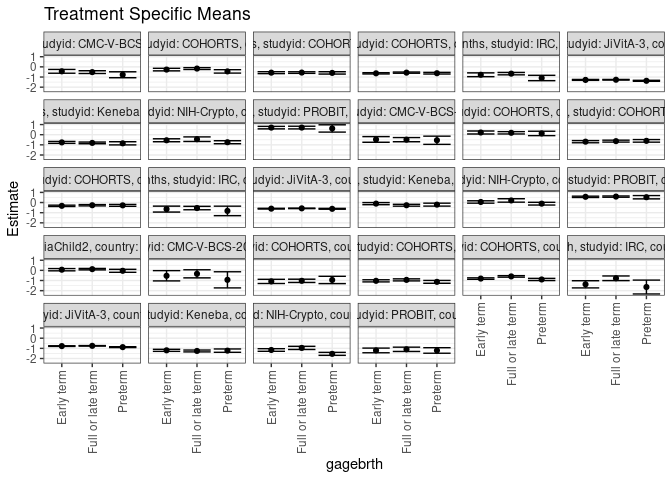

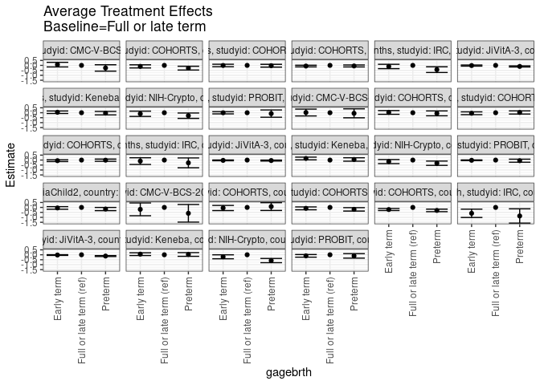

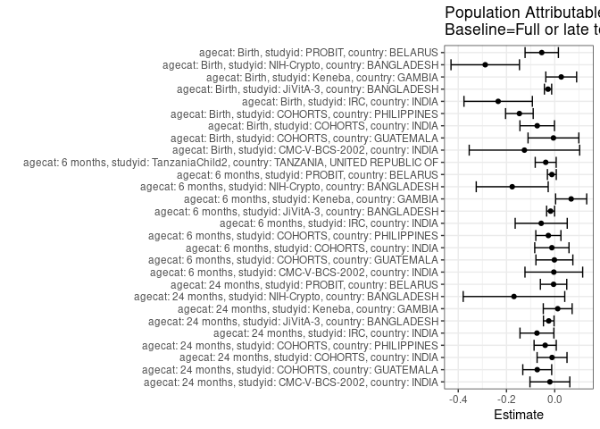

## Results Table

### Parameter: TSM

| agecat | studyid | country | intervention_level | baseline_level | estimate | ci_lower | ci_upper |
| --- | --- | --- | --- | --- | --- | --- | --- |
| Birth | CMC-V-BCS-2002 | INDIA | Full or late term | NA | -0.3391509 | -0.7395669 | 0.0612650 |
| Birth | CMC-V-BCS-2002 | INDIA | Preterm | NA | -0.9327273 | -1.7262167 | -0.1392379 |
| Birth | CMC-V-BCS-2002 | INDIA | Early term | NA | -0.5336364 | -1.0394385 | -0.0278343 |
| Birth | COHORTS | GUATEMALA | Full or late term | NA | -1.0304644 | -1.1911066 | -0.8698222 |
| Birth | COHORTS | GUATEMALA | Preterm | NA | -0.9439744 | -1.3031364 | -0.5848123 |
| Birth | COHORTS | GUATEMALA | Early term | NA | -1.0877778 | -1.2938420 | -0.8817136 |
| Birth | COHORTS | INDIA | Full or late term | NA | -0.9372333 | -1.0370314 | -0.8374351 |
| Birth | COHORTS | INDIA | Preterm | NA | -1.1320849 | -1.2708448 | -0.9933251 |
| Birth | COHORTS | INDIA | Early term | NA | -1.0302398 | -1.1342265 | -0.9262531 |
| Birth | COHORTS | PHILIPPINES | Full or late term | NA | -0.5952423 | -0.6680676 | -0.5224170 |
| Birth | COHORTS | PHILIPPINES | Preterm | NA | -0.8966839 | -1.0029151 | -0.7904528 |
| Birth | COHORTS | PHILIPPINES | Early term | NA | -0.8078276 | -0.8803654 | -0.7352898 |
| Birth | IRC | INDIA | Full or late term | NA | -0.7790610 | -1.0075397 | -0.5505824 |
| Birth | IRC | INDIA | Preterm | NA | -1.6409375 | -2.3248849 | -0.9569901 |
| Birth | IRC | INDIA | Early term | NA | -1.3733735 | -1.7262783 | -1.0204687 |
| Birth | JiVitA-3 | BANGLADESH | Full or late term | NA | -0.7517108 | -0.7767187 | -0.7267029 |
| Birth | JiVitA-3 | BANGLADESH | Preterm | NA | -0.8808784 | -0.9235453 | -0.8382115 |
| Birth | JiVitA-3 | BANGLADESH | Early term | NA | -0.7771971 | -0.8090739 | -0.7453204 |
| Birth | Keneba | GAMBIA | Full or late term | NA | -1.2565021 | -1.3477880 | -1.1652162 |
| Birth | Keneba | GAMBIA | Preterm | NA | -1.2259709 | -1.3888539 | -1.0630879 |
| Birth | Keneba | GAMBIA | Early term | NA | -1.1946183 | -1.2968744 | -1.0923623 |
| Birth | NIH-Crypto | BANGLADESH | Full or late term | NA | -0.9560625 | -1.1106784 | -0.8014466 |
| Birth | NIH-Crypto | BANGLADESH | Preterm | NA | -1.5421250 | -1.6875658 | -1.3966842 |
| Birth | NIH-Crypto | BANGLADESH | Early term | NA | -1.1613518 | -1.2896820 | -1.0330216 |
| Birth | PROBIT | BELARUS | Full or late term | NA | -1.0953163 | -1.3074747 | -0.8831580 |
| Birth | PROBIT | BELARUS | Preterm | NA | -1.2097002 | -1.4816971 | -0.9377033 |
| Birth | PROBIT | BELARUS | Early term | NA | -1.2052275 | -1.4363377 | -0.9741173 |
| 6 months | CMC-V-BCS-2002 | INDIA | Full or late term | NA | -0.4872406 | -0.6921396 | -0.2823415 |
| 6 months | CMC-V-BCS-2002 | INDIA | Preterm | NA | -0.5469281 | -0.9506624 | -0.1431939 |
| 6 months | CMC-V-BCS-2002 | INDIA | Early term | NA | -0.4661446 | -0.7446236 | -0.1876655 |

[output cut: 54 more lines]

### Parameter: E(Y)

| agecat | studyid | country | intervention_level | baseline_level | estimate | ci_lower | ci_upper |
| --- | --- | --- | --- | --- | --- | --- | --- |
| Birth | CMC-V-BCS-2002 | INDIA | NA | NA | -0.4648256 | -0.7643210 | -0.1653302 |
| Birth | COHORTS | GUATEMALA | NA | NA | -1.0358042 | -1.1559527 | -0.9156557 |
| Birth | COHORTS | INDIA | NA | NA | -1.0098535 | -1.0741510 | -0.9455561 |
| Birth | COHORTS | PHILIPPINES | NA | NA | -0.7417745 | -0.7882773 | -0.6952718 |
| Birth | IRC | INDIA | NA | NA | -1.0135366 | -1.2024730 | -0.8246002 |
| Birth | JiVitA-3 | BANGLADESH | NA | NA | -0.7794837 | -0.7988174 | -0.7601500 |
| Birth | Keneba | GAMBIA | NA | NA | -1.2295969 | -1.2924879 | -1.1667060 |
| Birth | NIH-Crypto | BANGLADESH | NA | NA | -1.2441513 | -1.3281130 | -1.1601897 |
| Birth | PROBIT | BELARUS | NA | NA | -1.1491782 | -1.3593933 | -0.9389630 |
| 6 months | CMC-V-BCS-2002 | INDIA | NA | NA | -0.4909778 | -0.6451612 | -0.3367945 |
| 6 months | COHORTS | GUATEMALA | NA | NA | 0.1864566 | 0.1024304 | 0.2704827 |
| 6 months | COHORTS | INDIA | NA | NA | -0.6460976 | -0.7081436 | -0.5840516 |
| 6 months | COHORTS | PHILIPPINES | NA | NA | -0.2920968 | -0.3336448 | -0.2505489 |
| 6 months | IRC | INDIA | NA | NA | -0.5999270 | -0.7403711 | -0.4594828 |
| 6 months | JiVitA-3 | BANGLADESH | NA | NA | -0.5906060 | -0.6106295 | -0.5705826 |
| 6 months | Keneba | GAMBIA | NA | NA | -0.1978013 | -0.2594875 | -0.1361150 |
| 6 months | NIH-Crypto | BANGLADESH | NA | NA | 0.0297622 | -0.0491685 | 0.1086930 |
| 6 months | PROBIT | BELARUS | NA | NA | 0.5741099 | 0.5141290 | 0.6340908 |
| 6 months | TanzaniaChild2 | TANZANIA, UNITED REPUBLIC OF | NA | NA | 0.0815655 | 0.0271217 | 0.1360092 |
| 24 months | CMC-V-BCS-2002 | INDIA | NA | NA | -0.5369143 | -0.6415957 | -0.4322329 |
| 24 months | COHORTS | GUATEMALA | NA | NA | -0.2397001 | -0.3082360 | -0.1711643 |
| 24 months | COHORTS | INDIA | NA | NA | -0.5717874 | -0.6260792 | -0.5174955 |
| 24 months | COHORTS | PHILIPPINES | NA | NA | -0.6079283 | -0.6449298 | -0.5709269 |
| 24 months | IRC | INDIA | NA | NA | -0.7414957 | -0.8350522 | -0.6479392 |
| 24 months | JiVitA-3 | BANGLADESH | NA | NA | -1.2935654 | -1.3174540 | -1.2696768 |
| 24 months | Keneba | GAMBIA | NA | NA | -0.7953404 | -0.8531640 | -0.7375168 |
| 24 months | NIH-Crypto | BANGLADESH | NA | NA | -0.6103502 | -0.7050157 | -0.5156847 |
| 24 months | PROBIT | BELARUS | NA | NA | 0.6981406 | 0.5843775 | 0.8119038 |

### Parameter: ATE

| agecat | studyid | country | intervention_level | baseline_level | estimate | ci_lower | ci_upper |
| --- | --- | --- | --- | --- | --- | --- | --- |
| Birth | CMC-V-BCS-2002 | INDIA | Full or late term | Full or late term | 0.0000000 | 0.0000000 | 0.0000000 |
| Birth | CMC-V-BCS-2002 | INDIA | Preterm | Full or late term | -0.5935763 | -1.4823723 | 0.2952197 |
| Birth | CMC-V-BCS-2002 | INDIA | Early term | Full or late term | -0.1944854 | -0.8395968 | 0.4506259 |
| Birth | COHORTS | GUATEMALA | Full or late term | Full or late term | 0.0000000 | 0.0000000 | 0.0000000 |
| Birth | COHORTS | GUATEMALA | Preterm | Full or late term | 0.0864900 | -0.3069605 | 0.4799406 |
| Birth | COHORTS | GUATEMALA | Early term | Full or late term | -0.0573134 | -0.3185956 | 0.2039688 |
| Birth | COHORTS | INDIA | Full or late term | Full or late term | 0.0000000 | 0.0000000 | 0.0000000 |
| Birth | COHORTS | INDIA | Preterm | Full or late term | -0.1948517 | -0.3657726 | -0.0239307 |
| Birth | COHORTS | INDIA | Early term | Full or late term | -0.0930065 | -0.2371346 | 0.0511216 |
| Birth | COHORTS | PHILIPPINES | Full or late term | Full or late term | 0.0000000 | 0.0000000 | 0.0000000 |
| Birth | COHORTS | PHILIPPINES | Preterm | Full or late term | -0.3014416 | -0.4302384 | -0.1726449 |
| Birth | COHORTS | PHILIPPINES | Early term | Full or late term | -0.2125853 | -0.3153728 | -0.1097978 |
| Birth | IRC | INDIA | Full or late term | Full or late term | 0.0000000 | 0.0000000 | 0.0000000 |
| Birth | IRC | INDIA | Preterm | Full or late term | -0.8618765 | -1.5829774 | -0.1407755 |
| Birth | IRC | INDIA | Early term | Full or late term | -0.5943125 | -1.0147221 | -0.1739028 |
| Birth | JiVitA-3 | BANGLADESH | Full or late term | Full or late term | 0.0000000 | 0.0000000 | 0.0000000 |
| Birth | JiVitA-3 | BANGLADESH | Preterm | Full or late term | -0.1291676 | -0.1775198 | -0.0808154 |
| Birth | JiVitA-3 | BANGLADESH | Early term | Full or late term | -0.0254863 | -0.0635944 | 0.0126218 |
| Birth | Keneba | GAMBIA | Full or late term | Full or late term | 0.0000000 | 0.0000000 | 0.0000000 |
| Birth | Keneba | GAMBIA | Preterm | Full or late term | 0.0305312 | -0.1561878 | 0.2172502 |
| Birth | Keneba | GAMBIA | Early term | Full or late term | 0.0618838 | -0.0751907 | 0.1989583 |
| Birth | NIH-Crypto | BANGLADESH | Full or late term | Full or late term | 0.0000000 | 0.0000000 | 0.0000000 |
| Birth | NIH-Crypto | BANGLADESH | Preterm | Full or late term | -0.5860625 | -0.7983338 | -0.3737912 |
| Birth | NIH-Crypto | BANGLADESH | Early term | Full or late term | -0.2052893 | -0.4062239 | -0.0043547 |
| Birth | PROBIT | BELARUS | Full or late term | Full or late term | 0.0000000 | 0.0000000 | 0.0000000 |
| Birth | PROBIT | BELARUS | Preterm | Full or late term | -0.1143839 | -0.3408214 | 0.1120537 |
| Birth | PROBIT | BELARUS | Early term | Full or late term | -0.1099112 | -0.2443768 | 0.0245544 |
| 6 months | CMC-V-BCS-2002 | INDIA | Full or late term | Full or late term | 0.0000000 | 0.0000000 | 0.0000000 |
| 6 months | CMC-V-BCS-2002 | INDIA | Preterm | Full or late term | -0.0596875 | -0.5124402 | 0.3930651 |
| 6 months | CMC-V-BCS-2002 | INDIA | Early term | Full or late term | 0.0210960 | -0.3246412 | 0.3668332 |

[output cut: 54 more lines]

### Parameter: PAR

| agecat | studyid | country | intervention_level | baseline_level | estimate | ci_lower | ci_upper |
| --- | --- | --- | --- | --- | --- | --- | --- |
| Birth | CMC-V-BCS-2002 | INDIA | Full or late term | NA | -0.1256746 | -0.3546086 | 0.1032594 |
| Birth | COHORTS | GUATEMALA | Full or late term | NA | -0.0053398 | -0.1106827 | 0.1000031 |
| Birth | COHORTS | INDIA | Full or late term | NA | -0.0726203 | -0.1442509 | -0.0009897 |
| Birth | COHORTS | PHILIPPINES | Full or late term | NA | -0.1465322 | -0.2037782 | -0.0892863 |
| Birth | IRC | INDIA | Full or late term | NA | -0.2344756 | -0.3762496 | -0.0927015 |
| Birth | JiVitA-3 | BANGLADESH | Full or late term | NA | -0.0277729 | -0.0428010 | -0.0127449 |
| Birth | Keneba | GAMBIA | Full or late term | NA | 0.0269052 | -0.0369453 | 0.0907556 |
| Birth | NIH-Crypto | BANGLADESH | Full or late term | NA | -0.2880888 | -0.4299879 | -0.1461897 |
| Birth | PROBIT | BELARUS | Full or late term | NA | -0.0538618 | -0.1229365 | 0.0152128 |
| 6 months | CMC-V-BCS-2002 | INDIA | Full or late term | NA | -0.0037373 | -0.1233532 | 0.1158787 |
| 6 months | COHORTS | GUATEMALA | Full or late term | NA | -0.0014097 | -0.0779841 | 0.0751646 |
| 6 months | COHORTS | INDIA | Full or late term | NA | -0.0118546 | -0.0828766 | 0.0591674 |
| 6 months | COHORTS | PHILIPPINES | Full or late term | NA | -0.0264062 | -0.0784989 | 0.0256866 |
| 6 months | IRC | INDIA | Full or late term | NA | -0.0560716 | -0.1639600 | 0.0518169 |
| 6 months | JiVitA-3 | BANGLADESH | Full or late term | NA | -0.0170671 | -0.0336213 | -0.0005128 |
| 6 months | Keneba | GAMBIA | Full or late term | NA | 0.0680908 | 0.0036827 | 0.1324989 |
| 6 months | NIH-Crypto | BANGLADESH | Full or late term | NA | -0.1762700 | -0.3254420 | -0.0270980 |
| 6 months | PROBIT | BELARUS | Full or late term | NA | -0.0119162 | -0.0302812 | 0.0064488 |
| 6 months | TanzaniaChild2 | TANZANIA, UNITED REPUBLIC OF | Full or late term | NA | -0.0374141 | -0.0808990 | 0.0060708 |
| 24 months | CMC-V-BCS-2002 | INDIA | Full or late term | NA | -0.0200919 | -0.1027220 | 0.0625383 |
| 24 months | COHORTS | GUATEMALA | Full or late term | NA | -0.0725118 | -0.1323946 | -0.0126291 |
| 24 months | COHORTS | INDIA | Full or late term | NA | -0.0110897 | -0.0730868 | 0.0509074 |
| 24 months | COHORTS | PHILIPPINES | Full or late term | NA | -0.0396110 | -0.0856264 | 0.0064044 |
| 24 months | IRC | INDIA | Full or late term | NA | -0.0738091 | -0.1440189 | -0.0035992 |
| 24 months | JiVitA-3 | BANGLADESH | Full or late term | NA | -0.0248139 | -0.0467816 | -0.0028463 |
| 24 months | Keneba | GAMBIA | Full or late term | NA | 0.0123711 | -0.0474612 | 0.0722033 |
| 24 months | NIH-Crypto | BANGLADESH | Full or late term | NA | -0.1689578 | -0.3795007 | 0.0415851 |
| 24 months | PROBIT | BELARUS | Full or late term | NA | -0.0047842 | -0.0594566 | 0.0498882 |